# Figure 5

## Packages

```r
library(readr)
library(dplyr)
library(purrr)
library(magrittr)
library(mgcv)
library(parallel)
```

## Capacity formula

The expression of the vectorial capacity as a function of as:

$$C(a) = M\times B^2 \frac{p(a)}{g(a)} e^{-\frac{g(a)}{m(a)}}$$
Where $M = 20$ is the ratio of mosquitoes to humans and $B = 1/3$ is the mosquito biting rate. These parameters were not studied here and will thus be assumed to be constants independent of age. Sporozoite prevalences $p(a)$ is informed by experiment 1, mosquitoes survival rates $g(a)$ are informed by experiment 2 and the parasite maturation rate is informed by experiment 3. We will assume that the vector competence and survival and the parasite maturation are independent from each other. We’ll further assume that $p(a)$ follows a beta distribution, the parameters of which will be estimated from the binomial estimate and its confidence interval from the presence/absence raw data and we will assume too that $m$ follows a gamma distribution, the parameters of which are estimated in a similar way. Values for $p(a)$ and $m$ will then be randomly drawn from these beta and gamma distributions respectively. As for the mosquito survival rates, we will simply compute the expected life expectancy from the non-parametrically bootstrapped data. This allows to preserve as well as possible the original distribution of the experimental data.

## Data from experiment 1

Loading and preparing the data:

```r
fig2 <- "data/fig2_sporozoite_data.txt" |>
  read_delim() |>
  filter(age_class != "8-day-old") |>
  mutate(intensity = 10^(-(Ct - 40) / 3.3))
```

A function that converts confidence intervals boundary values of a proportion into parameters of a probability distribution:

```r
ci2pars <- function(ci, f, pars, p = .95) {
  if (ci[2] < ci[1]) ci <-  ci[2:1]
  p <- (1 - p) / 2

  f_par <- function(par1, par2) {
    c(f(p, par1, par2), f(1 - p, par1, par2))
  }

  f_fit <- function(pars) {
    sum((f_par(pars[1], pars[2]) - ci)^2)
  }

  optim(pars, f_fit)$par
}
```

The shape parameters of the beta distribution of the mean sporozoites prevalences ($p(a)$):

```r
p_par0 <- fig2 |>
  group_by(age_class) |>
  summarize(x   = sum(positive), n = length(positive)) |>
  mutate(prop   = map2(x, n, prop.test),
         ci     = map(prop, extract2, "conf.int"),
         shapes = map(ci, ci2pars, qbeta, 1:2))

p_par <- p_par0 |>
  pull(shapes) |>
  setNames(sort(unique(fig2$age_class)))
```

The estimate and confidence interval:

```r
p_par0$prop |>
  map(extract, c("estimate", "conf.int")) |>
  map_dfr(unlist)
```

```
## # A tibble: 2 × 3
##   estimate.p conf.int1 conf.int2
##        <dbl>     <dbl>     <dbl>
## 1      0.545     0.473     0.615
## 2      0.729     0.672     0.779
```

A function that converts a vector into a 1-row tibble:

```r
vec2tibble <- function(x, names = NULL) {
  out <- as_tibble(matrix(x, 1))
  if (is.null(names)) return(out)
  setNames(out, names)
}
```

The parameters of the beta distribution:

```r
p_par |>
  map_dfr(vec2tibble, paste("shape", 1:2), .id = "group")
```

```
## # A tibble: 2 × 3
##   group      `shape 1` `shape 2`
##   <chr>          <dbl>     <dbl>
## 1 12-day-old      103.      86.0
## 2 4-day-old       192.      72.1
```

Let’s visualize these 2 distributions of probabilities:

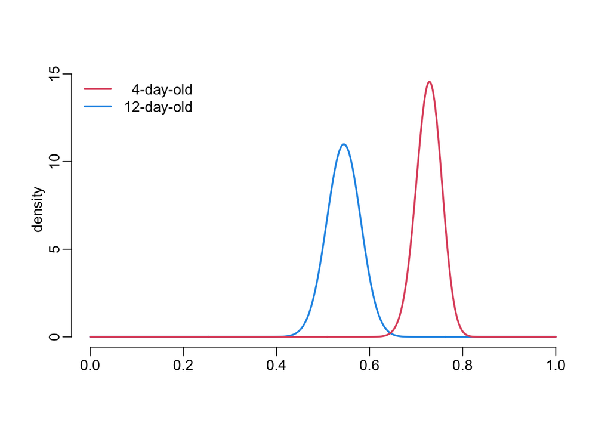

```r
lwd_val <- 2
col4 <- 2
col12 <- 4

xs <- seq(0, 1, le = 500)
ys <- map(p_par, ~ do.call(dbeta, c(list(xs), as.list(.x))))

plot(xs, ys[[1]], type = "l", xlab = NA, ylab = "density", lwd = lwd_val,
     ylim = c(0, max(unlist(ys))), col = col12)
lines(xs, ys[[2]], lwd = 2, col = col4)

legend("topleft", legend = c("  4-day-old", "12-day-old"), col = c(col4, col12),
       lwd = lwd_val, lty = 1, bty = "n")
```

## Experiment 2

Loading and preparing the data:

```r
fig3 <- "data/fig3_survival_data.txt" |>
  read_delim() |>
  filter(age_class != "8-day-old",
         !(age_class == "4-day-old" & infection_status != "Exposed-infected")) |>
  mutate(group = paste(age_class, infection_status, sep = " | ")) |>
  select(group, daysPI)
```

Generating the mortality data:

```r
mortality <- fig3 |>
  group_by(group) |>
  group_split() |>
  map(pull, daysPI) |>
  setNames(sort(unique(fig3$group)))
```

## Experiment 3

Loading and preparing the data:

```r
fig4 <- read_delim("data/fig4_EIP_data.txt")
```

```r
fig4a <- fig4 |>
  select(dpi, spz) |>
  na.exclude() |>
  mutate_at("spz", as.logical)
```

The parameters of the gamma distribution that models the distribution of the maturation rate:

```r
ci_val <- .95
alpha <- (1 - ci_val) / 2

mod <- glm(spz ~ dpi, binomial, fig4a)
invtransf <- family(mod)$linkinv

xs <- seq(min(fig4a$dpi), max(fig4a$dpi), le = 1000)
ys <- predict(mod, data.frame(dpi = xs), se.fit = TRUE)

nb_data <- nrow(mod$data)

ci <- tibble(xs  = xs,
             fit = invtransf(ys$fit),
             low = invtransf(ys$fit + qt(    alpha, nb_data) * ys$se.fit),
             upp = invtransf(ys$fit + qt(1 - alpha, nb_data) * ys$se.fit))

tmp <- c(filter(ci, .5 < upp)$xs[1], filter(ci, .5 < low)$xs[1])

inv_m <- ci2pars(tmp, qgamma, 1:2)
```

Estimate and confidence interval:

```r
ci |>
  mutate(d = abs(fit - .5)) |>
  arrange(d) |>
  pull(xs) |>
  first() |>
  c(tmp)
```

```
## [1] 14.58258 14.22222 15.03904
```

Let’s vizualize:

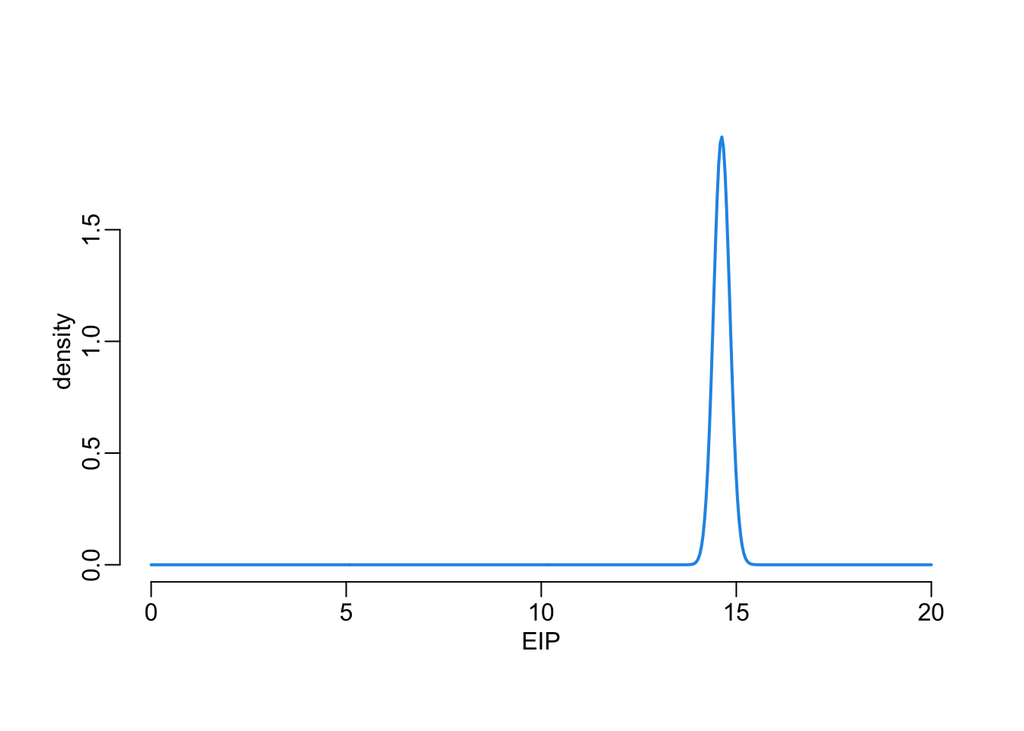

```r
xs <- seq(0, 20, le = 500)
ys <- dgamma(xs, inv_m[1], inv_m[2])
plot(xs, ys, type = "l", xlab = "EIP", ylab = "density", lwd = 2, col = 4)
```

## Simulating data

The simulator of a distribution of values of the vectorial capacity:

```r
M <- 20
B <- 1 / 3
MB2 <- M * B * B

simulate <- function(p, g, N = 1e4) {
  p_val <- do.call(rbeta, c(list(N), unname(p)))
  g_val <- replicate(N, 1 / mean(sample(g, replace = TRUE)))
  m_val <- do.call(rgamma, c(list(N), inv_m))
  MB2 * p_val * exp(- g_val * m_val) / g_val
}
```

Bootstrapping the mosquito survival data:

```r
n <- 1e4
tmp <- map(mortality, ~ replicate(n, 1 / mean(sample(.x, replace = TRUE))))
```

Checking for convergence:

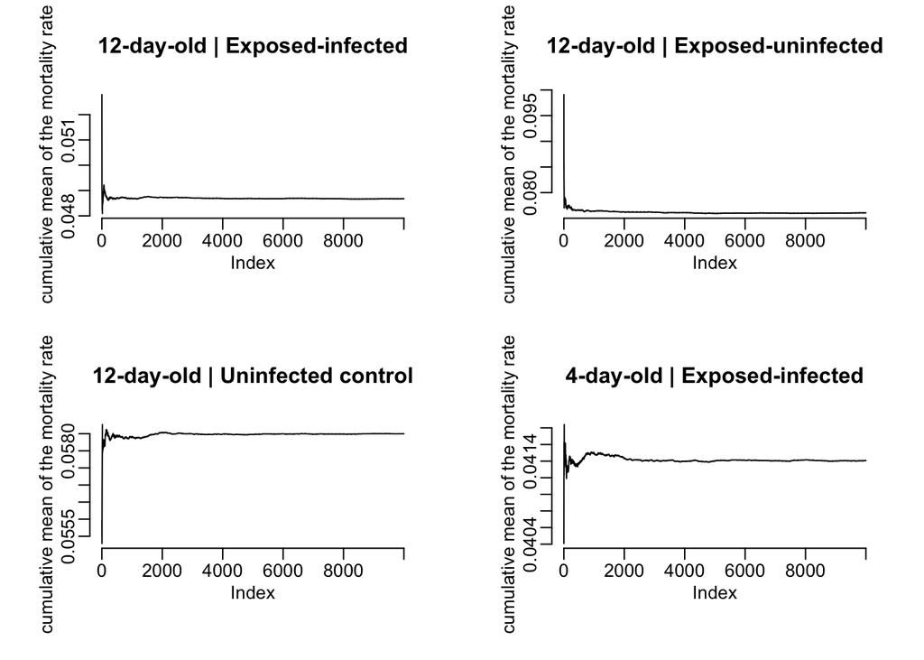

```r
opar <- par(mfrow = c(2, 2))
walk2(tmp, names(tmp),
      ~ plot(cummean(.x), main = .y, type = "l",
             ylab = "cumulative mean of the mortality rate"))
```

```r
par(opar)
```

Looking at the bootstrapped distribution of the mortality rates:

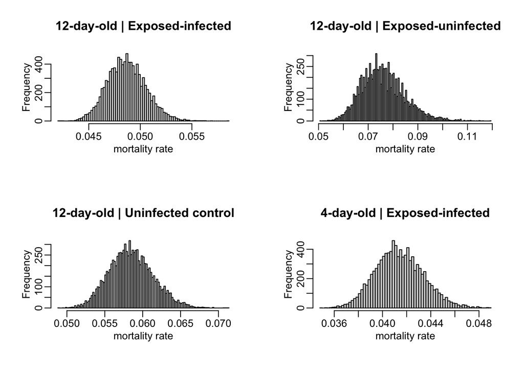

```r
opar <- par(mfrow = c(2, 2))
walk2(tmp, names(tmp), ~ hist(.x, main = .y, xlab = "mortality rate", n = 100))
```

```r
par(opar)
```

Performing the simulations for the 4 groups:

```r
sim_output <- mcmapply(simulate, rep(p_par, c(3, 1)), mortality, SIMPLIFY = FALSE, mc.cores = 4) |>
  setNames(c("sim_age12_ExpInf", "sim_age12_ExpNoinf", "sim_age12_Uninf", "sim_age4"))
```

If you are on Windows and the above line does not work, do this instead:

```r
sim_output <- mapply(simulate, rep(p_par, c(3, 1)), mortality, SIMPLIFY = FALSE) |>
  setNames(c("sim_age12_ExpInf", "sim_age12_ExpNoinf", "sim_age12_Uninf", "sim_age4"))
```

Checking that stationarity has been reached:

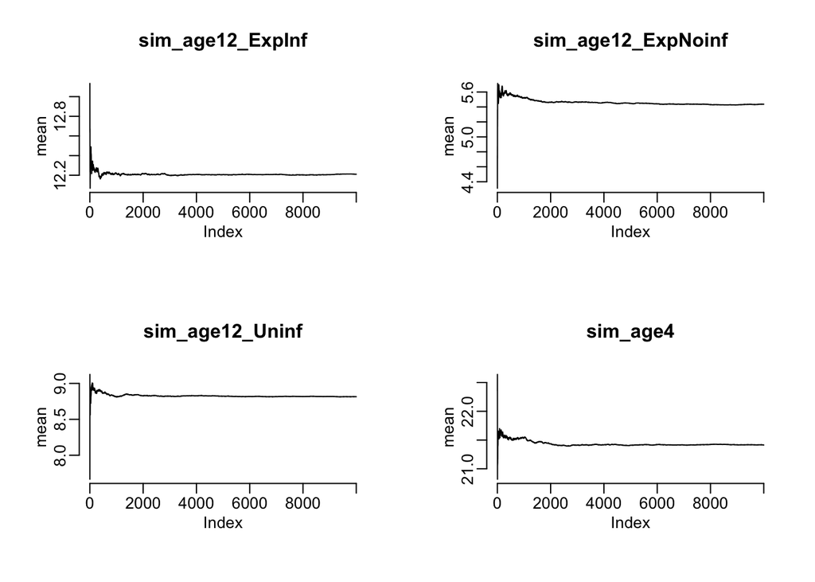

```r
opar <- par(mfrow = c(2, 2))
walk2(sim_output, names(sim_output),
      ~ plot(cummean(.x), main = .y, type = "l", ylab = "mean"))
```

```r
par(opar)
```

The ranges of values for the simulated vectorial capacities:

```r
map_dfr(sim_output,
        ~ setNames(as_tibble(matrix(range(.x), 1)), c("min", "max")),
        .id = "group")
```

```
## # A tibble: 4 × 3
##   group                min   max
##   <chr>              <dbl> <dbl>
## 1 sim_age12_ExpInf    8.55  16.4
## 2 sim_age12_ExpNoinf  1.42  11.0
## 3 sim_age12_Uninf     5.33  13.0
## 4 sim_age4           15.1   28.7
```

The means:

```r
map_dbl(sim_output, mean)
```

```
##   sim_age12_ExpInf sim_age12_ExpNoinf    sim_age12_Uninf           sim_age4
##          12.210468           5.436760           8.814776          21.413675
```

A function that computes the standard error of the mean:

```r
stderror <- function(x) sd(x) / sqrt(length(x))
```

Standard errors of the mean:

```r
map_dbl(sim_output, ~ stderror(.x))
```

```
##   sim_age12_ExpInf sim_age12_ExpNoinf    sim_age12_Uninf           sim_age4
##        0.011443203        0.013183886        0.009902596        0.018227450
```

A function that adds boxplots to a figure:

```r
add_boxplot <- function(x, y, eps = .1, lwd = 2, col = 1) {
  x <- as.vector(boxplot(x, plot = FALSE)$stats)
  segments2 <- function(...) segments(..., lwd = lwd, col = col)
  segments2(x[1], y, x[2], y)
  segments2(x[4], y, x[5], y)
  segments2(x[3], y - eps, x[3], y + eps)
  polygon(c(x[2], x[4], x[4], x[2]),
          rep(c(y - eps, y + eps), each = 2),
          lwd = lwd, border = col, col = adjustcolor(col, .5))
}
```

Computing densities of simulated VC data:

```r
from <- 0
to <- 30
densities <- map(sim_output, ~ density(.x), from = from, to = to)
```

Figure 5:

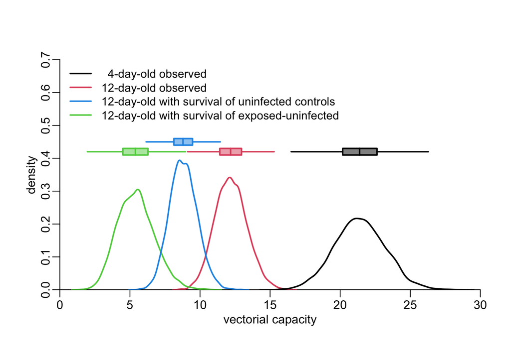

```r
y0 <- .42
y_step <- .03
eps <- .01

lines2 <- function(...) lines(..., lwd = 2)

plot(NA, xlim = c(from, to), ylim = c(0, .7), xaxs = "i", yaxs = "i",
     xlab = "vectorial capacity", ylab = "density")

walk2(densities, c(2, 3, 4, 1), ~ with(.x, lines2(x, y, col = .y)))

ind <- c(2, 3, 1, 4)
pwalk(list(sim_output[ind], c(0, 1, 0, 0), c(2, 3, 4, 1)[ind]),
      function(x, y, z) add_boxplot(x, y0 + y * y_step, col = z, eps = eps))

legend("topleft", cex = .95,
       legend = c("  4-day-old observed",
                  "12-day-old observed",
                  "12-day-old with survival of uninfected controls",
                  "12-day-old with survival of exposed-uninfected"),
       col = c(1, 2, 4, 3), lty = 1, lwd = 2, bty = "n")
```

## Figure 5SB

The inverse logit (i.e. logistic) function:

```r
inverse_logit <- function(x) {
  exp(x) / (1 + exp(x))
}
```

A function that computes proportions estimates together with confidence intervals:

```r
proportions <- function(x) {
  models <- x |>
    group_by(total_oocyst) |>
    group_map(~ glm(matrix(c(broken_oocyst, oocyst), ncol = 2) ~ 1, binomial, .x))

  estimates <- models |>
    map(coef) |>
    map(inverse_logit) |>
    bind_rows()

  ci <- models |>
    map(confint) |>
    map(inverse_logit) |>
    bind_rows()

  cbind(sort(unique(x$total_oocyst)), estimates, ci) |>
    setNames(c("total_oocyst", "estimate", "lower", "upper"))
}
```

A function that models the data:

```r
modelling <- function(x, bs = "tp") {
  out <- mgcv::gam(matrix(c(broken_oocyst, oocyst),
                          ncol = 2) ~ s(total_oocyst, bs = bs), binomial, x)
  out$data <- x
  out
}
```

Where the possible values for `bs` are:

- `tp`: thin plate
- `ts`: thin plate with a smoothing penalty
- `ds`: Duchon spline (generalization of the thin plate)
- `cr`: cubic regression
- `cs`: cubic regression with a shrinkage
- `cc`: cyclic cubic regression
- `sos`: splines on a sphere
- `bs`: B-spline
- `ps`: P-spline
- `cp`: cyclic P-spline
- `re`: random effect
- `mrf`: Markov random field
- `gp`: Gaussian process
- `so`: soap film smooths

A function that computes the predictions of a model:

```r
predictions <- function(x, ci = .95) {
  data <- x$data
  qt_val <- qt(1 - (1 - ci) / 2, nrow(data))
  xs <- seq(min(data$total_oocyst), max(data$total_oocyst), le = 512)

  predict(x, data.frame(total_oocyst = xs), se.fit = TRUE) |>
    extract(c("fit", "se.fit")) |>
    as_tibble() |>
    bind_cols(total_oocyst = xs) |>
    mutate(lower = inverse_logit(fit - qt_val * se.fit),
           upper = inverse_logit(fit + qt_val * se.fit),
           fit   = inverse_logit(fit)) |>
    select(-se.fit) |>
    select(total_oocyst, everything())
}
```

A tuned version of the `polygon()` function:

```r
polygon2 <- function(x, y1, y2, col = 1, alpha = .2, ...) {
  polygon(c(x, rev(x)), c(y1, rev(y2)), border = NA,
          col = adjustcolor(col, alpha), ...)
}
```

A function that adds a model predictions to a plot:

```r
add_predictions <- function(x, col = 1) {
  with(x, {
    polygon2(total_oocyst, lower, upper, col)
    lines(total_oocyst, fit, col = col)
  })
}
```

A tuning of `arrows()`:

```r
arrows2 <- function(...) arrows(..., length = .05, angle = 90, code = 3)
```

A function that makes the figure with a given smoother:

```r
plot_proportions <- function(props, eps = .15) {
  props |>
  filter(age_class == "4-day-old") |>
  with(plot(total_oocyst - eps, estimate, ylim = 0:1,
            xlab = "total number of oocysts",
            ylab = "proportion of ruptured oocysts"))

  props |>
    filter(age_class == "12-day-old") |>
    with(points(total_oocyst + eps, estimate, col = 2))

  props |>
    filter(age_class == "4-day-old", !is.nan(upper)) |>
    with(arrows2(total_oocyst - eps, lower, total_oocyst - eps, upper))

  props |>
    filter(age_class == "12-day-old", !is.nan(upper)) |>
    with(arrows2(total_oocyst + eps, lower, total_oocyst + eps, upper, col = 2))
}
```

```r
add_model_predictions <- function(data, s) {
  data |>
    group_by(age_class) |>
    group_split() |>
    map(modelling, s) |> # tp, cr, bs, ps
    map(predictions) |>
    walk2(2:1, add_predictions)
}
```

Make figure S5B:

```r
make_figS5B <- function(props, data, s = "tp", eps = .15) {
  plot_proportions(props, eps = .15)
  add_model_predictions(data, s)
  legend("topleft", legend = c("4-day-old", "12-day-old"),
         col = 1:2, lty = 1, bty = "n")
}
```

Preparing the data:

```r
fig4b <- fig4 |>
  select(age_class, oocyst, broken_oocyst) |>
  na.exclude() |>
  mutate(total_oocyst = oocyst + broken_oocyst) |>
  filter(total_oocyst > 0)
```

Computing the proportions of ruptured oocysts per age class and total number of oocysts:

```r
props <- fig4b |>
  group_by(age_class) |>
  group_modify(~ proportions(.x)) |>
  ungroup()
```

Make figure S5B:

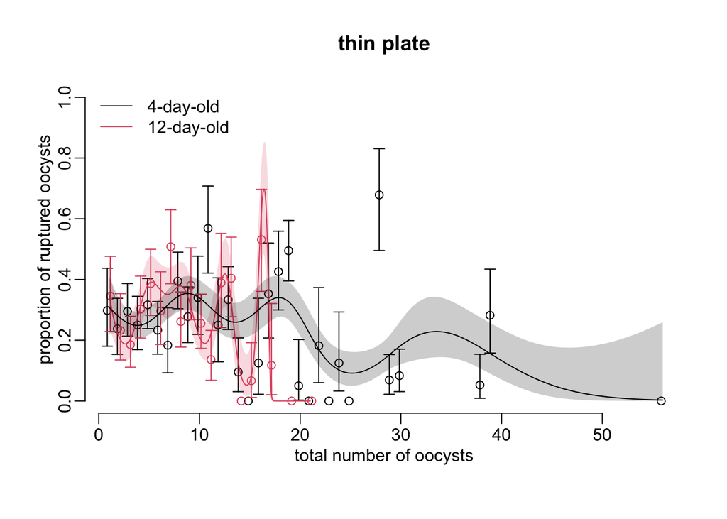

```r
make_figS5B(props, fig4b, "tp")
title("thin plate")
```

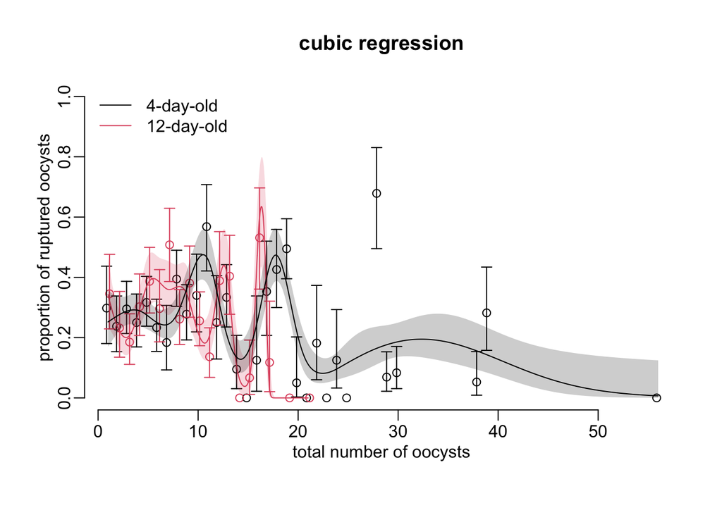

```r
make_figS5B(props, fig4b, "cr")
title("cubic regression")
```

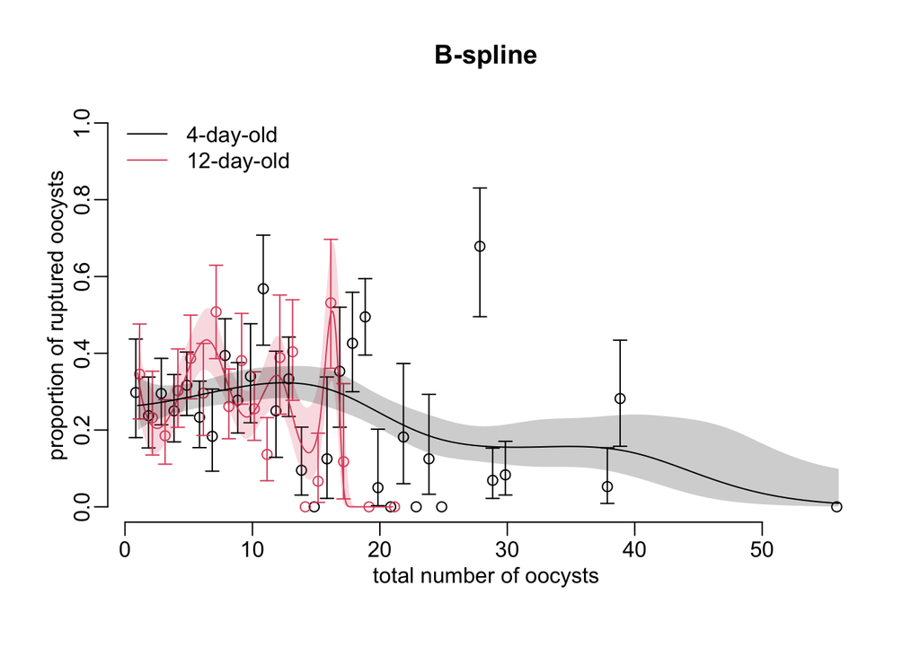

```r
make_figS5B(props, fig4b, "bs")
title("B-spline")
```

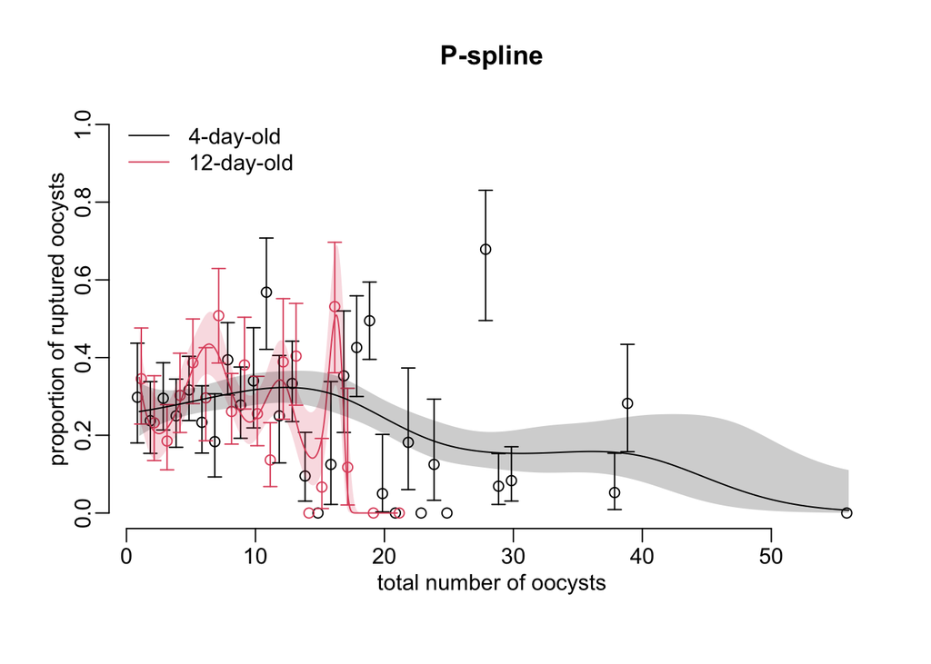

```r
make_figS5B(props, fig4b, "ps")
title("P-spline")
```

## Titi

```r
eip <- fig4 |>
  filter(8 < dpi, dpi < 15, oocyst > 0) |>
  mutate(total_oocyst = broken_oocyst + oocyst,
         prop = broken_oocyst / total_oocyst)
```

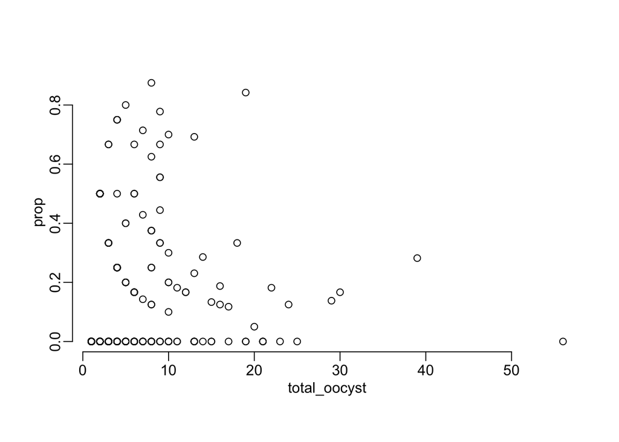

```r
with(eip, plot(total_oocyst, prop))
```

Relaxing filter:

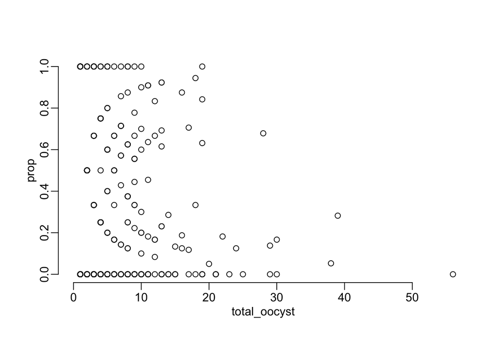

```r
fig4 |>
#  filter(8 < dpi, dpi < 15, oocyst > 0) |>
  mutate(total_oocyst = broken_oocyst + oocyst,
         prop = broken_oocyst / total_oocyst) |>
  with(plot(total_oocyst, prop))
```